# Evidencia 1

Antonio Maldonado - A01176753

2023-03-20

# **Introduccion**

## Describir la situacion problema del socioformador**

El socioformador en nuestro caso es el conjunto directivo del area de Servicio Social en el Tecnologico de Monterrey. La cuestion principal se enfoca princialmente en tener una automatizacion y organizacion mas concreta por parte del socioformador en cuanto a la utilizacion de los datos en las actividades.

## Describir cómo el proceso de análisis exploratorio de los datos permite facilitar el proceso de toma de decisiones relacionadas con la situación problema del Socio Formador.

Eploratory Data Analysis es utlizado principalmente para investigar datos y encontrar caracteristicas de estos y asi poder implementarlos en las visualizaciones de datos. Mas aun, existen formas de utlizar este tipo de analisis para encontrar las relaciones entre las varoables que estan siendo analizadas. El sofio formador puede tener una mejor experiencia en la toma de deciociones con este analisis ya que con los resultados que sean obtenidos se podran entonces validar si los recursos que estan siendo utilizados pueden cumplir con los objetivos o metas para la situacion problema.

## Describir cómo el proceso de análisis exploratorio de los datos pudiera contribuir al diseño de alguna o varias soluciones a la situación problema del Socio Formador.

Existen muchas formas por las cuales el analisis exploratorio de datos puede tener una contribucion a varias soluciones al problema que esta ocurriendo. El analisis exploratorio permite la manipilacion de datos que pueden llegar a contribuir a una mejor visualizacion. De igual forma, este tipo de analisis permite al analista determinar si los datos que estan siendo utilizados son validos o estadisticamente significativos.

```r
library(foreign)
library(dplyr)
library(forcats)
library(ggplot2)
library(janitor)
library(Hmisc)
library(psych)
library(naniar)
library(dlookr)
library(corrplot)
library(jtools)
library(readxl)
library(knitr)
library(arsenal)
library(survival)
```

# Analisis de Datos

## Importe del dataset

```r
evidence_data <- read_excel("evidence.data.xlsx")
View(evidence_data)
```

## Analizas la informacion en el dataset

```r
summary(evidence_data)
```

```
##      Index         No. plazas       Carrera            Escuela
##  Min.   :  0.0   Min.   :  1.00   Length:501         Length:501
##  1st Qu.:130.0   1st Qu.:  5.00   Class :character   Class :character
##  Median :258.0   Median : 15.00   Mode  :character   Mode  :character
##  Mean   :257.3   Mean   : 36.63
##  3rd Qu.:386.0   3rd Qu.: 47.00
##  Max.   :512.0   Max.   :170.00
##    Semestre         Semana Tec de Inducción Nombre experiencia
##  Length:501         Length:501              Length:501
##  Class :character   Class :character        Class :character
##  Mode  :character   Mode  :character        Mode  :character
##
##
##
##  Categoria de proyecto Clave de materia        CRN             Grupo
##  Length:501            Length:501         Min.   : 200.0   Min.   :101.0
##  Class :character      Class :character   1st Qu.: 249.0   1st Qu.:109.0
##  Mode  :character      Mode  :character   Median : 249.0   Median :112.0
##                                           Mean   : 394.5   Mean   :114.8
##                                           3rd Qu.: 281.0   3rd Qu.:114.0
##                                           Max.   :2103.0   Max.   :154.0
##  Estatus de Iris       Duración     Comentarios        Lista de espera
##  Length:501         Min.   : 60.0   Length:501         Length:501
##  Class :character   1st Qu.:100.0   Class :character   Class :character
##  Mode  :character   Median :100.0   Mode  :character   Mode  :character
##                     Mean   :136.6
##                     3rd Qu.:200.0
##                     Max.   :200.0
##      OSF             OSF titulo           ...18
##  Length:501         Length:501         Length:501
##  Class :character   Class :character   Class :character
##  Mode  :character   Mode  :character   Mode  :character
##
##
##
```

## Convertir las variables cualitativas a factores para el analisis descriptivo

```r
evidence_data$Escuela<-as.factor(evidence_data$Escuela)
evidence_data$Carrera<-as.factor(evidence_data$Carrera)
evidence_data$Semestre<-as.factor(evidence_data$Semestre)
evidence_data$`Semana Tec de Inducción`<-as.factor(evidence_data$`Semana Tec de Inducción`)
evidence_data$OSF<-as.factor(evidence_data$OSF)
evidence_data$`Nombre experiencia`<-as.factor(evidence_data$`Nombre experiencia`)
evidence_data$`Categoria de proyecto`<-as.factor(evidence_data$`Categoria de proyecto`)
evidence_data$`Clave de materia`<-as.factor(evidence_data$`Clave de materia`)
```

## Identificando variables faltantes

```r
colSums(is.na(evidence_data))
```

```
##                   Index              No. plazas                 Carrera
##                       0                       0                       0
##                 Escuela                Semestre Semana Tec de Inducción
##                       0                       0                       0
##      Nombre experiencia   Categoria de proyecto        Clave de materia
##                       0                       0                       0
##                     CRN                   Grupo         Estatus de Iris
##                       0                       0                       0
##                Duración             Comentarios         Lista de espera
##                       0                       0                       0
##                     OSF              OSF titulo                   ...18
##                       0                       0                     459
```

# **Descriptive Analysis**

```r
evidence_data2<-evidence_data %>% filter(Escuela %in% c('Ambiente Construido','Derecho, economia y relaciones internacionales','Estudios creativos','Ingeneria y ciencias','Negocios','Salud','Null'))
tab1<-tableby(Escuela ~ `No. plazas` + Duración  , data=evidence_data2, test=FALSE)
summary(tab1, title= "Summary Statistics por No. Plzas y Duracion por Escuela", width=45)
```

```
##
##
## Table: Summary Statistics por No. Plzas y Duracion por Escuela
##
## |                            | Ambiente Construido (N=31) | Derecho, economia y relaciones internacionales (N=43) | Estudios creativos (N=32) | Ingeneria y ciencias (N=262) | Negocios (N=105) |    Salud (N=8)    |  Total (N=481)   |
## |:---------------------------|:--------------------------:|:-----------------------------------------------------:|:-------------------------:|:----------------------------:|:----------------:|:-----------------:|:----------------:|
## |**No. plazas**              |                            |                                                       |                           |                              |                  |                   |                  |
## |&nbsp;&nbsp;&nbsp;Mean (SD) |      42.484 (48.864)       |                    20.233 (23.179)                    |      28.562 (40.883)      |       33.424 (44.559)        | 52.733 (53.783)  |  66.750 (51.922)  | 37.274 (46.449)  |
## |&nbsp;&nbsp;&nbsp;Range     |      1.000 - 159.000       |                    1.000 - 135.000                    |      2.000 - 170.000      |       1.000 - 167.000        | 1.000 - 169.000  | 10.000 - 144.000  | 1.000 - 170.000  |
## |**Duración**                |                            |                                                       |                           |                              |                  |                   |                  |
## |&nbsp;&nbsp;&nbsp;Mean (SD) |      145.161 (50.588)      |                   181.395 (39.375)                    |     156.875 (53.788)      |       131.145 (46.628)       | 131.048 (47.066) |  100.000 (0.000)  | 137.713 (48.996) |
## |&nbsp;&nbsp;&nbsp;Range     |     100.000 - 200.000      |                   100.000 - 200.000                   |     60.000 - 200.000      |       60.000 - 200.000       | 60.000 - 200.000 | 100.000 - 100.000 | 60.000 - 200.000 |
```

# **Tableros Graficos**

## Relacion entre Escuela y Duracion

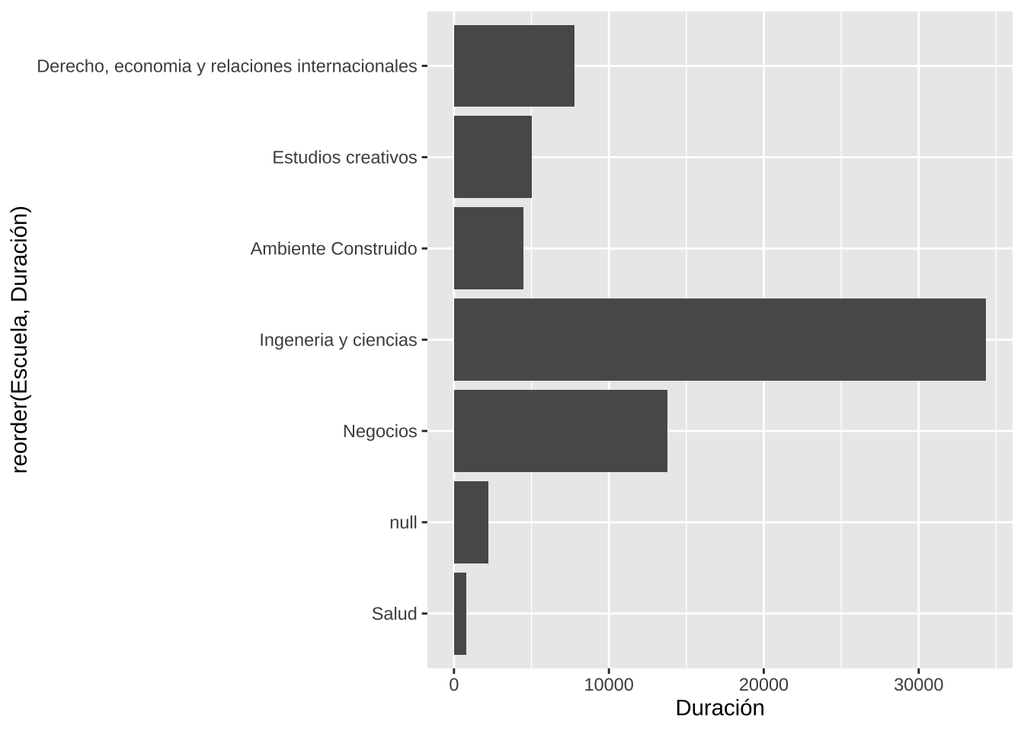

```r
ED1<-evidence_data %>% select(Escuela,Duración) %>% group_by(Escuela) %>% summarise(Duración=sum(Duración)) %>% arrange(desc(Duración))
ggplot(evidence_data, aes(x=reorder(Escuela,Duración), y=Duración)) +
  geom_bar(stat="identity")+
  coord_flip()
```

## Relacion entre Grupos y duracion por escuela

```r
ED2<-evidence_data %>% select(Escuela,Grupo,CRN,Duración) %>% group_by(Escuela) %>%
  summarise(Grupo=sum(Grupo),CRN=sum(CRN),Duración=sum(Duración)) %>% arrange(desc(Grupo))
```

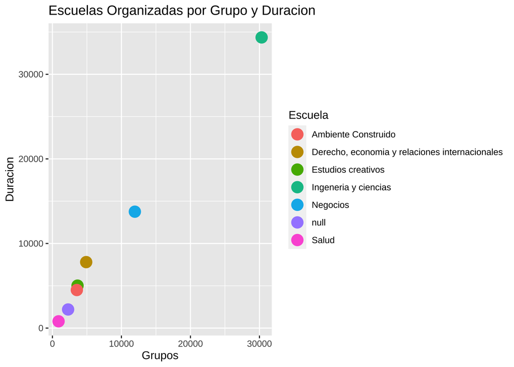

```r
ggplot(ED2, aes(x=Grupo, y=Duración, color=Escuela, shape=Escuela)) +
  geom_point(shape=19,size=5)+
   labs(title="Escuelas Organizadas por Grupo y Duracion",
       x="Grupos", y = "Duracion")
```

Generamos un scatter plot para hacer un analisis de los datos espaciados. Podemos observar que existe una collecion de escuelas que tienen una magnitud similar en cuanto a el numero de grupos y la duracion de los proyectos. Podemos ver la escuela de Negocios y la escuela de Ingieneria y CIencias tienen las cantidades mas altas.

## Alumnos en lista de espera por carrera

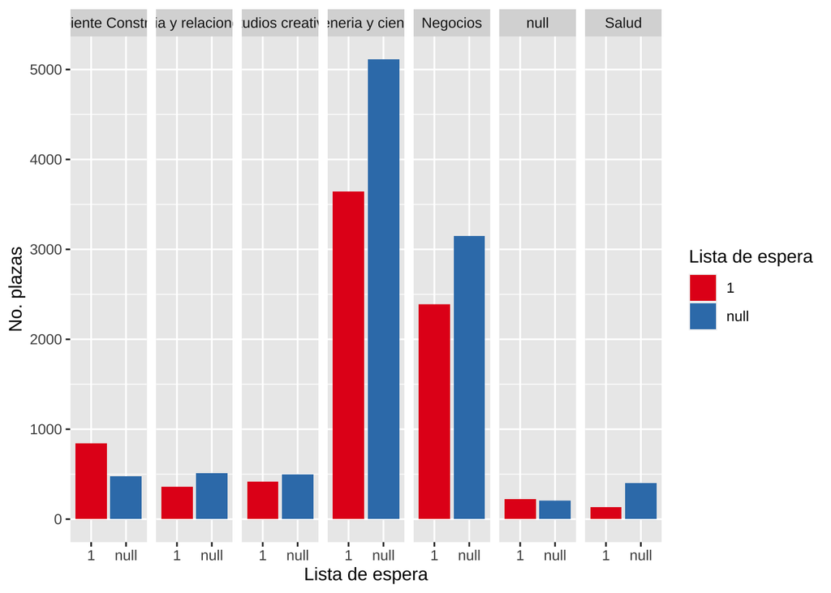

```r
ED3<-evidence_data %>% select(Escuela,`No. plazas`,Grupo, `Lista de espera`)
ggplot(ED3, aes(x=`Lista de espera`, y=`No. plazas`, fill=`Lista de espera`)) +
  geom_bar(stat="identity") +
  facet_grid(~Escuela) + scale_fill_brewer(palette = "Set1")
```

## Nivel de correlacion entre los numeros de plazas y el semestre de los estudiantes

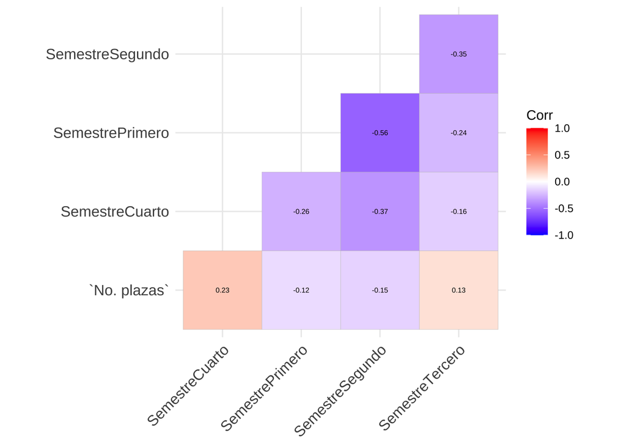

```r
library(ggcorrplot)
ED4<-evidence_data %>% select(`No. plazas`,Semestre)
model.matrix(~0+., data=ED4) %>%
  cor(use="pairwise.complete.obs") %>%
  ggcorrplot(show.diag=FALSE, type="lower", lab=TRUE, lab_size=2)
```

El grafico de correlacion nos demuestra si existen algun tipo de correlacion entre el numero de plazas y el tipo de semestre en el que los estudiantes estan. De acuerdo con el grafico, los estidantes que forman parte del cuarto semestre y de del tercer semestre tienen una relacion mas alta con el numero de plazas. Esto tiene sentido ya que la mayoria de los alumnos usualmente realizan su servicio social durante sus semestres mas tardios.

## Que socio formador tiene el mayor numero de dispersion

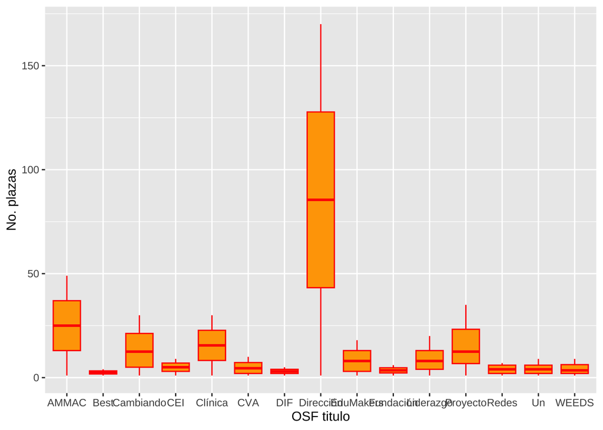

```r
ED5<-evidence_data %>% select(`No. plazas`,`OSF titulo`) %>% arrange(desc(`No. plazas`))
ggplot(ED5, aes(x=`OSF titulo`, y=`No. plazas`)) +
  geom_boxplot(color="red", fill="orange", alpha=1)
```

El diagrama de boxplot nos permite identificar que tan dispersos estan los datos. El grafico demuestra que la Direccion de Servicio Social- Apdrendizajes para todos tiene la dispersion de datos mas altas. Esto prueba que dentro de esta Organizacion Socio Formadora tenemos valores que estan mas alejados del promedio.

## Cuantas plazas hay por categoria del proyecto

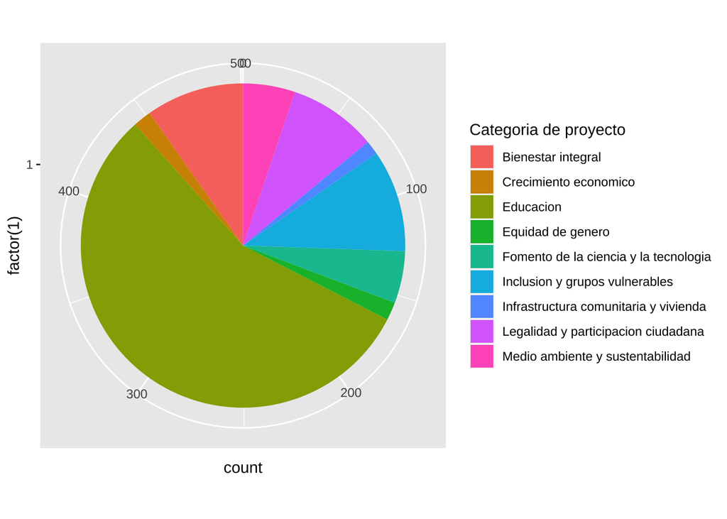

```r
ED6<-evidence_data %>% select(`No. plazas`,`Categoria de proyecto`)
ggplot(ED6, aes(x=factor(1), fill=`Categoria de proyecto`))+
  geom_bar(width = 1)+
  coord_polar("y")
```

El grafico de pie nos demuestra una proporcion en cuanto a las cantidades de estudiantes que se encuentran por categoiria de proyectos. Se puede obsrvar que los proyectos que caen dentro del area de Educacion tienen la proporcion mas alta, mientras que los que se enfocan en infaestructura comunitaria y vivienda tienen el numero mas bajo.

# **Soluciones**

   Mientras existen multiples razones de porque los numeros fijos se estan dando de esta forma, la razon principal se atrbuye a que la carga de trabajo es mucho mas baja relativo hacia diferentes secciones. Esto incentiviza a los estudiantes a buscar proyectos dentro de categorias donde no requeriran un alto nivel de trabajo pero recibiran el mismo numero de horas.

   Es por esto que Servicio Social puede econtrar formas para poder interesar a mas estudiantes en diferentes categorias. Programas para generar creditos extra, oportunidades laborales de exploracion o incluso beneficios dentro de la Universidad generaria un ineres adicional para los estudiantes. De esta forma, el sistema de Servicio Social no estara tan saturado de estudiantes que deseen entrar en un pequeño numero de organizaciones en una categoria.
2. La segunda solucion implica la seleccion y distribucion de diferentes programas a diferentes estudiantes en base a su semestre. Se creo un diagrama de correlacion en donde fue posible identificar que existe una correlacion mas alta en cuanto a el numero de plazas y los alumnos que estan en tercer o cuarto semestre.

   Esto sucede principalmente porque los estudiantes de semestres tempranos no buscan como prioridad acabar sus horas de servicio social. Basandonos en este hecho, se podria generar alguna prioridad por parte de Servicio Social hacia estudiantes que son de semestres mas avanzados hacia programas que tienen el mayor numero de demanda. Esta dispersion permitira tener un conteo mas simple de todos los estudiantes y sus projecciones hacia cuantos estudiantes entraran hacia respectivas areas.

# **Sugerencias**

## 1. Buscar convenios con otros departamentos para intentar buscar incentivos para que los estudiantes busquen entrar a diferentes programas categoricos y evitar que se saturen ciertas categorias.

## 2. Intentar proporcionar una preferencia a los alumnos de semestres mas avanzados ya que se observo una correlacion mas altas entre el numero de semestre y las plazas.

## 3. Reducir el numero de estudiantes en lista de espera categorizandolos escuela. El diagrama que se creo demuestra una dispersion incoherente entre escuelas asi que esto podria tener un mayor impacto para la organizacion futura de los datos.

# **Conclusiones**

## -La escuela de salud resulto ser la escuela con el rango minimo mas alto indicando que existen una distribucion congruente entre los estudiantes de esta escuela.

# **Referencias**

## Descriptive Analytics

https://online.hbs.edu/blog/post/descriptive-analytics

## Exploratory Data Analysis

https://towardsdatascience.com/exploratory-data-analysis-8fc1cb20fd15